# Impact and Analysis of Weather Events

CSV Pitchers

December 5, 2017

## Storm Event Database

### About Dataset

The National Centers for Environmental Information (NCEI) regularly receives Storm Data from the National Weather Service (NWS). This data set consists of state wise occurrence of Event type in USA like Tornado, Thunderstorm Wind and Hail, Marine strong wind, Flash flood, Heavy rain, Heavy snow, Funnel Cloud, Extensive Heat and also contains data regarding locations, fatalities, injuries, damage, narratives and any other event specific information which can be used for information and analysis by business sectors, insurance companies, hazard mitigation, policy makers etc. (NCDC, 2017)

### Data for Analysis

We are using the data of 2016 to analyze the effect of event types on economy (property damage and crop damage) and casualties (injuries and deaths). Furthermore, We have used data of 2011-2016 to see the trends of top events we have found in 2016.Overall there are 51 attributes/columns in each data file.

### License

The information on NOAA web page is in the public domain unless specifically annotated otherwise (copyright may be held elsewhere) and may therefore be used freely by the public.  
Additional information disclaimer and copyright notice can be found in [Disclaimer and Copyright Notice](https://www.nodc.noaa.gov/about/disclaimer.html) .

### Metadata : Information available to understand and interprete data

Storm events database contains the records with information on

- Occurrence of Storms and other significant events which is likely to cause more damage, death and injuries.
- Other rare, unusual weather phenomenon like snow flurries

51 Columns/datafields are there in data which can be defined as shown in [Storm Data Export Format](http://www1.ncdc.noaa.gov/pub/data/swdi/stormevents/csvfiles/Storm-Data-Export-Format.docx)

### Issues Encountered with data

- Columns having similar properties are there such as BEGIN_YEARMONTH, BEGIN_DAY, BEGIN_TIME and BEGIN_DATE_TIME. Similar case is found for END DATE as well.
- When looking into 2016 data, 11690 out of 55959 have blank values in DAMAGE_PROPERTY though it also have values 0.00 K in other rows.
- 11355 out of 55959 have blank values in DAMAGE_CROPS in 2016 data. Like in DAMAGE_PROPERTY, this field also contains value 0.00K.
- Negligible row i.e. 45 out of 55959 data in 2016 have source UNKNOWN.

### Remediation steps

*We are dropping the columns which have redundant data such as ‘BEGIN_YEARMONTH’, ‘END_YEARMONTH’, ‘state_fips’ as these values are combination of columns present in the data set and for the analysis we can keep the data granular so that we can represent the result in more granular way.

*We are also removing the columns ‘EPISODE_NARRATIVE’, ‘event_narrative’ and ‘DATA_SOURCE’ as these are nominal data and it will hard to analyize them in R, but we will be using them seperately as remarks. We have checked for the duplicate values and removed the duplicate values for each question.

### Data Cleaning & Analysis Steps

#### Loading the data

We have used the necessary functions and loaded the data from 2011-2016 into the respective dataframe as:

```r
dataset2016 <- read.csv('StormEvents_details-ftp_v1.0_d2016_c20170918.csv',header = TRUE,stringsAsFactors = F, na.strings = c("",NULL,'NA'))
dataset2015 <- read.csv('StormEvents_details-ftp_v1.0_d2015_c20170918.csv',header = TRUE,stringsAsFactors = F,na.strings = c("",NULL,'NA'))
dataset2014 <- read.csv('StormEvents_details-ftp_v1.0_d2014_c20170718.csv',header = TRUE,stringsAsFactors = F,na.strings = c("",NULL,'NA'))
dataset2013 <- read.csv('StormEvents_details-ftp_v1.0_d2013_c20170519.csv',header = TRUE,stringsAsFactors = F,na.strings = c("",NULL,'NA'))
dataset2012 <- read.csv('StormEvents_details-ftp_v1.0_d2012_c20170519.csv',header = TRUE,stringsAsFactors = F,na.strings = c("",NULL,'NA'))
dataset2011 <- read.csv('StormEvents_details-ftp_v1.0_d2011_c20170519.csv',header = TRUE,stringsAsFactors = F,na.strings = c("",NULL,'NA'))
```

These data are then combined into one dataframe as :

```r
dataAll <- rbind(dataset2016,dataset2015,dataset2014,dataset2013,dataset2012,dataset2011)
```

Internal structure of data has been checked

```r
str(dataAll)
```

```
## 'data.frame':    376788 obs. of  51 variables:
##  $ BEGIN_YEARMONTH   : int  201607 201607 201607 201607 201607 201607 201612 201612 201612 201602 ...
##  $ BEGIN_DAY         : int  15 15 16 8 8 8 4 4 4 25 ...
##  $ BEGIN_TIME        : int  1715 1725 1246 1755 1810 1910 300 400 400 1157 ...
##  $ END_YEARMONTH     : int  201607 201607 201607 201607 201607 201607 201612 201612 201612 201602 ...
##  $ END_DAY           : int  15 15 16 8 8 8 5 5 5 25 ...
##  $ END_TIME          : int  1715 1725 1246 1755 1810 1910 600 500 500 1841 ...
##  $ EPISODE_ID        : int  108769 108769 108812 105872 105872 105872 111575 111575 111575 103607 ...
##  $ EVENT_ID          : int  651823 651825 651828 635287 635296 635301 665685 665686 665687 619257 ...
##  $ STATE             : chr  "SOUTH CAROLINA" "SOUTH CAROLINA" "NORTH CAROLINA" "TENNESSEE" ...
##  $ STATE_FIPS        : int  45 45 37 47 47 47 56 56 56 24 ...
##  $ YEAR              : int  2016 2016 2016 2016 2016 2016 2016 2016 2016 2016 ...
##  $ MONTH_NAME        : chr  "July" "July" "July" "July" ...
##  $ EVENT_TYPE        : chr  "Heavy Rain" "Thunderstorm Wind" "Thunderstorm Wind" "Thunderstorm Wind" ...
##  $ CZ_TYPE           : chr  "C" "C" "C" "C" ...
```

[output cut: 37 more lines]

Duplicates have been checked

```r
dupAll<- unique(dataAll)
nrow(dataAll)
```

```
## [1] 376788
```

```r
nrow(dupAll)
```

```
## [1] 376788
```

NA is replaced with 0

```r
dataAll_na <- dataAll
dataAll[is.na(dataAll)] <- 0
```

Values of amount in damage property and damage crops containing M in data is multiplied by 1000 to turn it into K and “K” and “M are then removed from data

```r
dataall_update <- dataAll

index1 <- (substr(dataall_update$DAMAGE_PROPERTY,nchar(dataall_update$DAMAGE_PROPERTY),nchar(dataall_update$DAMAGE_PROPERTY)))=="M"
index2 <- (substr(dataall_update$DAMAGE_CROPS,nchar(dataall_update$DAMAGE_CROPS),nchar(dataall_update$DAMAGE_CROPS)))=="M"
index3 <- (substr(dataall_update$DAMAGE_PROPERTY,nchar(dataall_update$DAMAGE_PROPERTY),nchar(dataall_update$DAMAGE_PROPERTY)))=="K"
index4 <- (substr(dataall_update$DAMAGE_CROPS,nchar(dataall_update$DAMAGE_CROPS),nchar(dataall_update$DAMAGE_CROPS)))=="K"


dataall_update$DAMAGE_PROPERTY[index1] <-
  as.numeric(substr(dataall_update$DAMAGE_PROPERTY[index1],1,nchar(dataall_update$DAMAGE_PROPERTY[index1])-1))*1000

dataall_update$DAMAGE_CROPS[index2] <-
  as.numeric(substr(dataall_update$DAMAGE_CROPS[index2],1,nchar(dataall_update$DAMAGE_CROPS[index2])-1))*1000

dataall_update$DAMAGE_PROPERTY[index3] <-
  as.numeric(substr(dataall_update$DAMAGE_PROPERTY[index3],1,nchar(dataall_update$DAMAGE_PROPERTY[index3])-1))

dataall_update$DAMAGE_CROPS[index4] <-
  as.numeric(substr(dataall_update$DAMAGE_CROPS[index4],1,nchar(dataall_update$DAMAGE_CROPS[index4])-1))
```

Fields Damage property and Damage crops have to be changed into numeric datatypto allow any further analysis

```r
dataall_update$DAMAGE_PROPERTY <- as.numeric(as.character(dataall_update$DAMAGE_PROPERTY))
dataall_update$DAMAGE_CROPS <- as.numeric(as.character(dataall_update$DAMAGE_CROPS))
```

Replacing NA with 0

```r
dataall_update_na <- dataall_update
dataall_update[is.na(dataall_update)] <- 0
```

Relevant Statistics are being checked, in this case,summary is taken.

We have to mainly focus on damage property, damage crops, direct injuries, indirect injuries, direct death and indirect deaths.

```r
summary(dataall_update)
```

```
##  BEGIN_YEARMONTH    BEGIN_DAY       BEGIN_TIME   END_YEARMONTH
##  Min.   :201101   Min.   : 1.00   Min.   :   0   Min.   :201101
##  1st Qu.:201204   1st Qu.: 6.00   1st Qu.: 700   1st Qu.:201204
##  Median :201308   Median :15.00   Median :1450   Median :201308
##  Mean   :201338   Mean   :14.85   Mean   :1258   Mean   :201338
##  3rd Qu.:201505   3rd Qu.:23.00   3rd Qu.:1800   3rd Qu.:201505
##  Max.   :201612   Max.   :31.00   Max.   :2359   Max.   :201612
##     END_DAY         END_TIME      EPISODE_ID        EVENT_ID
##  Min.   : 1.00   Min.   :   0   Min.   : 45914   Min.   :266353
##  1st Qu.: 9.00   1st Qu.:1112   1st Qu.: 62087   1st Qu.:372418
##  Median :18.00   Median :1609   Median : 78298   Median :472047
##  Mean   :17.04   Mean   :1485   Mean   : 78525   Mean   :472064
##  3rd Qu.:25.00   3rd Qu.:1919   3rd Qu.: 94922   3rd Qu.:571798
##  Max.   :31.00   Max.   :2359   Max.   :117998   Max.   :709335
##     STATE             STATE_FIPS         YEAR       MONTH_NAME
##  Length:376788      Min.   : 1.00   Min.   :2011   Length:376788
##  Class :character   1st Qu.:19.00   1st Qu.:2012   Class :character
##  Mode  :character   Median :31.00   Median :2013   Mode  :character
##                     Mean   :32.69   Mean   :2013
##                     3rd Qu.:46.00   3rd Qu.:2015
##                     Max.   :99.00   Max.   :2016
##   EVENT_TYPE          CZ_TYPE             CZ_FIPS         CZ_NAME
##  Length:376788      Length:376788      Min.   :  1.00   Length:376788
##  Class :character   Class :character   1st Qu.: 25.00   Class :character
##  Mode  :character   Mode  :character   Median : 63.00   Mode  :character
##                                        Mean   : 99.55
##                                        3rd Qu.:117.00
##                                        Max.   :876.00
##      WFO            BEGIN_DATE_TIME    CZ_TIMEZONE
##  Length:376788      Length:376788      Length:376788
##  Class :character   Class :character   Class :character
##  Mode  :character   Mode  :character   Mode  :character
##
##
##
##  END_DATE_TIME      INJURIES_DIRECT    INJURIES_INDIRECT
##  Length:376788      Min.   :0.00e+00   Min.   :  0.00000
##  Class :character   1st Qu.:0.00e+00   1st Qu.:  0.00000
##  Mode  :character   Median :0.00e+00   Median :  0.00000
##                     Mean   :5.29e-02   Mean   :  0.01306
```

[output cut: 50 more lines]

```
##  Max.   :185.000                                         Max.   : 70.50
##    BEGIN_LON          END_LAT          END_LON        EPISODE_NARRATIVE
##  Min.   :-170.89   Min.   :-14.39   Min.   :-170.83   Length:376788
##  1st Qu.: -92.85   1st Qu.:  0.00   1st Qu.: -92.85   Class :character
##  Median : -80.52   Median : 33.46   Median : -80.51   Mode  :character
##  Mean   : -55.97   Mean   : 23.46   Mean   : -55.96
##  3rd Qu.:   0.00   3rd Qu.: 39.29   3rd Qu.:   0.00
##  Max.   : 171.37   Max.   : 70.26   Max.   : 171.37
##  EVENT_NARRATIVE    DATA_SOURCE
##  Length:376788      Length:376788
##  Class :character   Class :character
##  Mode  :character   Mode  :character
##
##
##
```

For this analysis 2016 data has been used to determine the number of even types that occurred on the basis of location. In the data state, longitudes and latitudes are available for the information on location.

```r
library(knitr)
library(ggplot2)
# making subset to extract state and event type
Dataset_new <- dataset2016[,c(9,13)]

# Added new column Named region for States-
Dataset_new$Region[Dataset_new$STATE %in% c("CONNECTICUT","MAINE","MASSACHUSETTS", "NEW HAMPSHIRE","RHODE ISLAND", "VERMONT", "NEW JERSEY", "NEW YORK", "PENNSYLVANIA")] <- "Northeast"

Dataset_new$Region[Dataset_new$STATE%in% c("ILLINOIS", "INDIANA", "MICHIGAN", "OHIO", "WISCONSIN", "IOWA", "KANSAS", "MINNESOTA", "MISSOURI", "NEBRASKA","NORTH DAKOTA", "SOUTH DAKOTA")] <- "Midwest"

Dataset_new$Region[Dataset_new$STATE %in% c("DELAWARE", "FLORIDA",
                                            "GEORGIA", "MARYLAND",
                                            "NORTH CAROLINA", "SOUTH CAROLINA",
                                            "VIRGINIA", "DISTRICT OF COLUMBIA",
                                            "WEST VIRGINIA", "ALABAMA", "KENTUCKY",
                                            "MISSISSIPPI", "TENNESSEE", "ARKANSAS",
                                            "LOUISIANA", "OKLAHOMA", "TEXAS"
)] <- "South"

Dataset_new$Region[Dataset_new$STATE %in% c("ARIZONA", "COLORADO", "IDAHO",
                                            "MONTANA", "NEVADA", "NEW MEXICO",
                                            "UTAH", "WYOMING", "ALASKA",
                                            "CALIFORNIA", "HAWAII", "OREGON",
                                            "WASHINGTON"
)] <- "West"

south_data <-Dataset_new[Dataset_new$Region == 'South',]
north_data <-Dataset_new[Dataset_new$Region == 'Northeast',]
midwest_data <-Dataset_new[Dataset_new$Region == 'Midwest',]
west_data <-Dataset_new[Dataset_new$Region == 'West',]


# Intensity plotting for events vs state-- each point is scaled according to number of occurence
# South Region-
south_table <- table(midwest_data)

table_s<- as.data.frame(south_table)
names(table_s)<- c("State","Event","Region","Frequency")
summary(table_s$Frequency)
```

```
##    Min. 1st Qu.  Median    Mean 3rd Qu.    Max.
##    0.00    0.00    6.00   49.84   46.00 1034.00
```

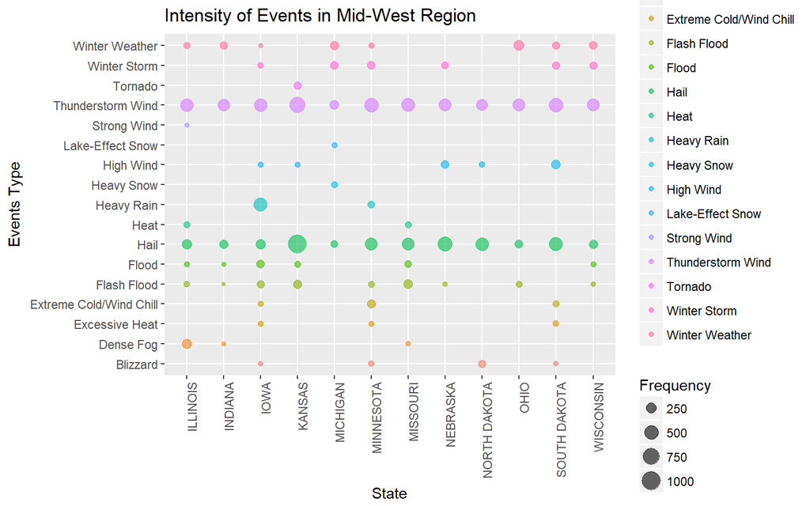

```r
p<- subset(table_s,subset=Frequency>50, select= c(State,Event,Frequency))

qplot(p$State, p$Event, data=p, size=Frequency,col= Event, alpha=I(6/10), main="Intensity of Events in Mid-West Region",
      xlab="State", ylab="Events Type")+theme(axis.text.x = element_text(angle = 90, hjust =1))
```

Here We can see that number or frequency of occurrence of event types are represented by the size of the circle as shown in Frequency. This graph gives the information on number of events occurring in a state. We can see that Thunderstorm and Hail are occurring in every state. Comparison is possible of any particular event types between state. Similar graphs are drawn for other regions as well.

```r
# North Region-
north_table <- table(north_data)

table_n<- as.data.frame(north_table)
names(table_n)<- c("State","Event","Region","Frequency")
summary(table_n$Frequency)
```

```
##    Min. 1st Qu.  Median    Mean 3rd Qu.    Max.
##     0.0     0.0     1.0    17.9    13.5   486.0
```

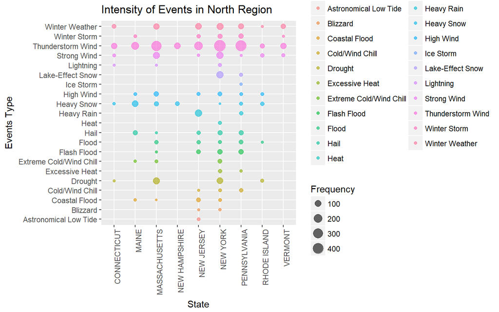

```r
p2<- subset(table_n,subset=Frequency>10, select= c(State,Event,Frequency))

qplot(p2$State, p2$Event, data=p2, size=Frequency,col= Event, alpha=I(6/10), main="Intensity of Events in North Region",
      xlab="State", ylab="Events Type")+theme(axis.text.x = element_text(angle = 90, hjust =1))
```

```r
# MidWest Region-

midwest_table <- table(midwest_data)

table_mw<- as.data.frame(midwest_table)
names(table_mw)<- c("State","Event","Region","Frequency")
summary(table_mw$Frequency)
```

```
##    Min. 1st Qu.  Median    Mean 3rd Qu.    Max.
##    0.00    0.00    6.00   49.84   46.00 1034.00
```

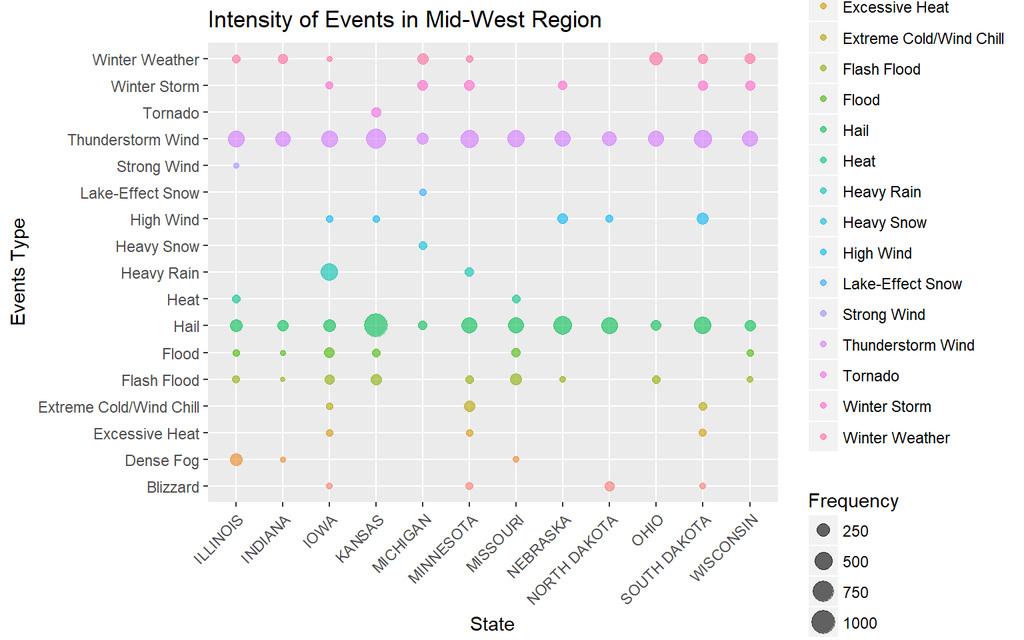

```r
p1<- subset(table_mw,subset=Frequency>50, select= c(State,Event,Frequency))

qplot(p1$State, p1$Event, data=p1, size=Frequency,col= Event, alpha=I(6/10), main="Intensity of Events in Mid-West Region",
      xlab="State", ylab="Events Type")+theme(axis.text.x = element_text(angle = 45, hjust =1))
```

```r
# West Region-
west_data <- na.omit(west_data)
west_table <- table(west_data)
table_w<- as.data.frame(west_table)
names(table_w)<- c("State","Event","Region","Frequency")
summary(table_w$Frequency)
```

```
##    Min. 1st Qu.  Median    Mean 3rd Qu.    Max.
##    0.00    0.00    1.00   19.85   10.00  756.00
```

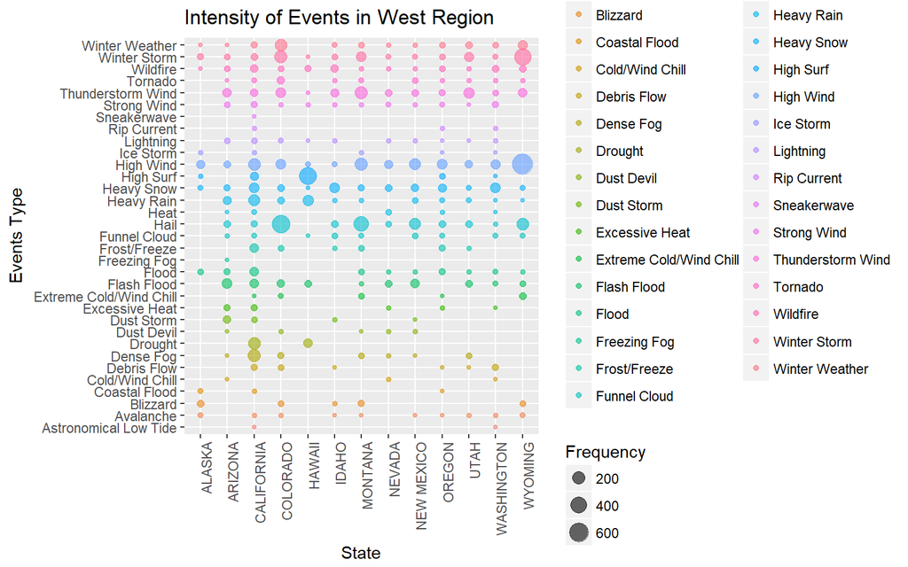

```r
p4<- subset(table_w,subset=Frequency>0, select= c(State,Event,Frequency))

qplot(p4$State, p4$Event, data=p4, size=Frequency,col= Event, alpha=I(6/10), main="Intensity of Events in West Region",
      xlab="State", ylab="Events Type")+theme(axis.text.x = element_text(angle = 90, hjust =1))
```

#### 2. What is the amunt of damage (property & Crops) caused by each event for year 2016?

For this analysis, we have used the column event types, property damage and crop damage. To focus more on the events which are causing the most damages, we have taken top 10 events instead of considering all the events available in data.

```r
library(dplyr)
library(ggplot2)
library(scales)
library(reshape)

#extract 2016 data
data_2016 = subset (dataall_update, YEAR == 2016)
Dataset4_na_addcol <- data_2016

# adding column TOTAL_DAMAGE
Dataset4_na_addcol$TOTAL_DAMAGE <- (Dataset4_na_addcol$DAMAGE_PROPERTY + Dataset4_na_addcol$DAMAGE_CROPS)

## topten events
Damage <- aggregate(cbind(DAMAGE_PROPERTY, DAMAGE_CROPS,TOTAL_DAMAGE) ~ EVENT_TYPE, data = Dataset4_na_addcol, FUN = sum)

#topten events by property damage

propertyDamage <- Damage[order(Damage$DAMAGE_PROPERTY, decreasing = T), ]
topTen_propertyDamage <- propertyDamage[1:10, ]
topTen_propertyDamage1 <- data.frame(apply(topTen_propertyDamage, 2, unclass))

#topten events by crop damage
cropDamage <- Damage[order(Damage$DAMAGE_CROPS, decreasing = T), ]
topTen_cropDamage <- cropDamage[1:10, ]
topTen_cropDamage1 <- data.frame(apply(topTen_cropDamage, 2, unclass))


#topten events by total(property+ crop) damage
totalDamage <- Damage[order(Damage$TOTAL_DAMAGE, decreasing = T), ]
topTen_totalDamage <- totalDamage[1:10, ]
topTen_totalDamage1 <- data.frame(apply(topTen_totalDamage, 2, unclass))
```

Plots for above data have been created as follows:

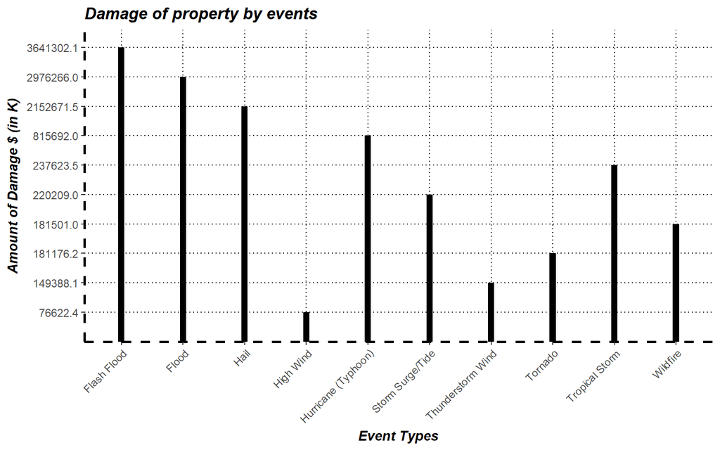

```r
black.bold.italic.text <- element_text(face = "bold.italic", color = "black")
#plot for damage property

p <-  ggplot(topTen_propertyDamage1, aes(x=EVENT_TYPE, y = DAMAGE_PROPERTY))+geom_bar(stat = "identity", width = 0.1, fill="black")

p+ theme(axis.text.x = element_text(angle = 45, hjust =1),axis.line = element_line(size = 1, colour = "black", linetype = "dashed"),panel.background = element_rect(fill = "white"),panel.grid.major = element_line(colour = "black", linetype = "dotted"), panel.grid.minor = element_line(colour = "black", linetype = "dotted"),
         title = black.bold.italic.text, axis.title = black.bold.italic.text)+
  labs(title = "Damage of property by events",
       x="Event Types", y="Amount of Damage $ (in K)")
```

Here FlashFlood is the most devastating for property in 2016

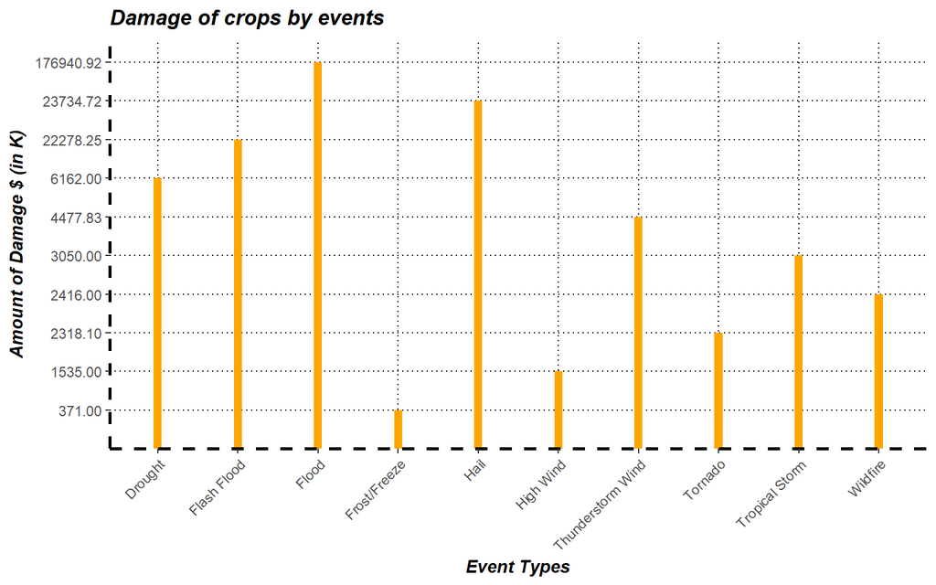

```r
#plot for damage crop

p1 <-  ggplot(topTen_cropDamage1, aes(x=EVENT_TYPE, y = DAMAGE_CROPS))+geom_bar(stat = "identity", width = 0.1, fill ="orange")
p1+ theme(axis.text.x = element_text(angle = 45, hjust =1),axis.line = element_line(size = 1, colour = "black", linetype = "dashed"),panel.background = element_rect(fill = "white"),panel.grid.major = element_line(colour = "black", linetype = "dotted"), panel.grid.minor = element_line(colour = "black", linetype = "dotted"),
          title = black.bold.italic.text, axis.title = black.bold.italic.text)+
  labs(title = "Damage of crops by events",
       x="Event Types", y="Amount of Damage $ (in K)")
```

Flood is the most devastating for crops

Summarized plot of total damage is shown below

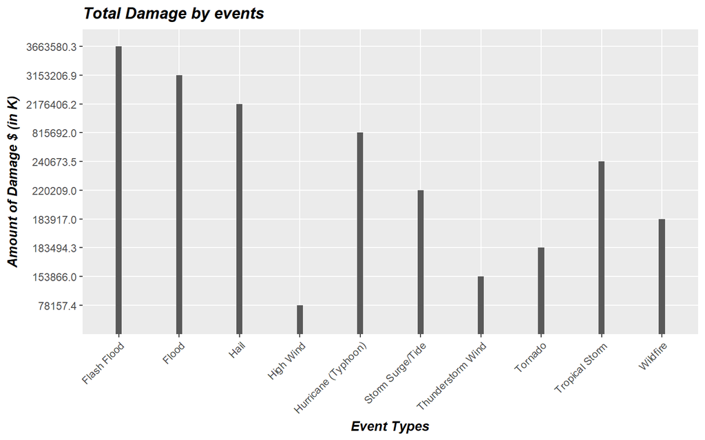

```r
#plot for Total damage

p2 <-  ggplot(topTen_totalDamage1, aes(x=EVENT_TYPE, y = TOTAL_DAMAGE))+geom_bar(stat = "identity", width = 0.1)

p2+ theme(axis.text.x = element_text(angle = 45, hjust =1),
          title = black.bold.italic.text, axis.title = black.bold.italic.text)+
  labs(title = "Total Damage by events",
       x="Event Types", y="Amount of Damage $ (in K)")
```

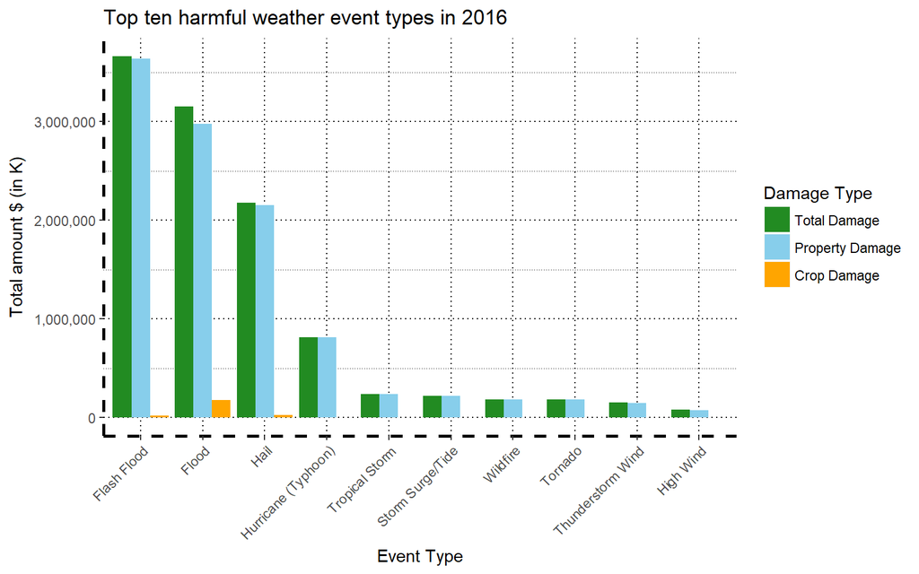

```r
#plot for overall damage with respective damage in property and crops
p3 <- melt(topTen_totalDamage[, c("EVENT_TYPE", "TOTAL_DAMAGE", "DAMAGE_PROPERTY", "DAMAGE_CROPS")], id.vars = 1)

ggplot(p3, aes(x = reorder(EVENT_TYPE, -value), y = value)) + geom_bar(stat = "identity", aes(fill = variable), position = "dodge")+scale_y_continuous(labels = comma)+ theme(axis.text.x = element_text(angle = 45, hjust = 1), axis.line = element_line(size = 1, colour = "black", linetype = "dashed"),
                                                                                                                                                                              panel.background = element_rect(fill = "white"), panel.grid.major = element_line(colour = "black", linetype = "dotted"),
                                                                                                                                                                              panel.grid.minor = element_line(colour = "black", linetype = "dotted")) + xlab("Event Type") + ylab("Total amount $ (in K)") + ggtitle("Top ten harmful weather event types in 2016") +
  scale_fill_manual(name = "Damage Type", values = c("forestgreen", "skyblue", "orange"),
                    labels = c("Total Damage",  "Property Damage", "Crop Damage"))
```

From the above graph we can see that event types which are most devastating has more effects on property than crop when compared on the basis of amount.

#### 3. What is trend of top 5 events occurred in 2016 troughout the duration of 2011 -2016

We have taken top 5 events on the basis of total damage on property and crop. We are trying to look into the trend of these top eventsfrom 2011 - 2016. We have top 5 events : FlashFlood, Flood, Hail, Hurricane, Tropical Storm. Along with these, thunderstorm is also taken since it is one of the most happening uniform event in 2016.

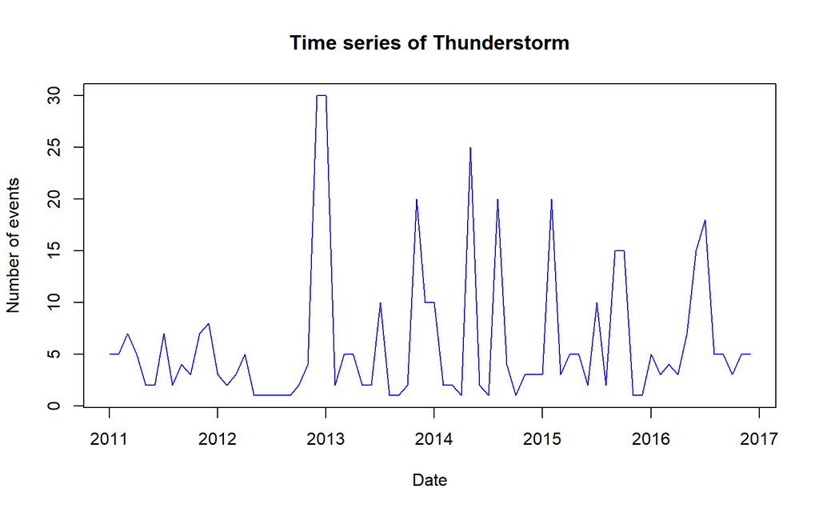

```r
#Add column which contains the sum of amount of damage property and damage crops
dataall_na_addcol <- dataall_update[,c(8,9,11,12,13,18,25,26)]
dataall_na_addcol$DAMAGE_OVERALL <- (dataall_na_addcol$DAMAGE_PROPERTY + dataall_na_addcol$DAMAGE_CROPS)


# plotting

dataall_na_addcol$date <- as.POSIXct(dataall_na_addcol$BEGIN_DATE_TIME,format = "%d-%b-%y %H:%M:%S")

# making subset of the damage as thuderstorm is the most occuring event each year-
dataset_thunder <- subset(dataall_na_addcol,EVENT_TYPE=="Thunderstorm Wind")

dataset_thunder <- dataset_thunder[c(9,10)]
dataset_thunder$date <- as.Date(dataset_thunder$date)

# for relative scaling, removed data with damage 0 and greater than 50000
dataset_thunder1 <- subset(dataset_thunder,subset = DAMAGE_OVERALL>0 & DAMAGE_OVERALL<50000 , select = c(DAMAGE_OVERALL,date))

# plot time series
ts_thunder<- ts(dataset_thunder1$DAMAGE_OVERALL,start=c(2011,1),end=c(2016,12),frequency = 12)

plot(ts_thunder, type="l",col="blue", xlab = "Date",ylab="Number of events", main = "Time series of Thunderstorm")
```

Similar trend plots are done for top 5 events as below

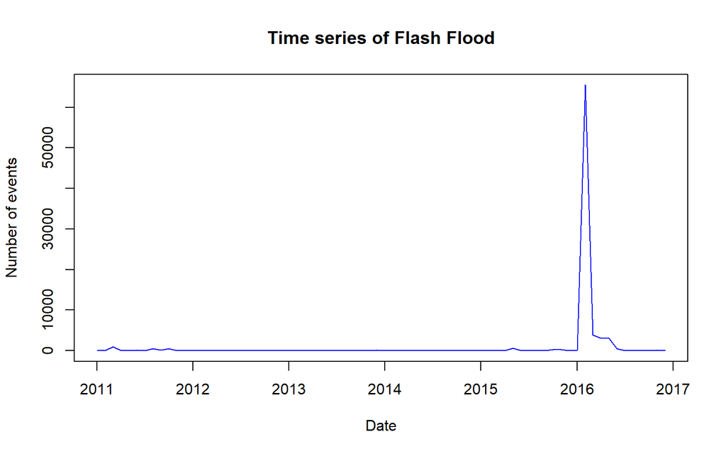

```r
# Creating plot for top 5 damage causing events- 1. Flash Flood
dataset_flashflood <- subset(dataall_na_addcol,EVENT_TYPE=="Flash Flood")
dataset_flashflood <- dataset_flashflood[c(9,10)]
dataset_flashflood$date <- as.Date(dataset_flashflood$date)
dataset_flashflood1 <- subset(dataset_flashflood,subset = DAMAGE_OVERALL>0  , select = c(DAMAGE_OVERALL,date))

ts_flashflood<- ts(dataset_flashflood1$DAMAGE_OVERALL,start=c(2011,1),end=c(2016,12),frequency = 12)

plot(ts_flashflood, type="l",col="blue", xlab = "Date",ylab="Number of events", main = "Time series of Flash Flood")
```

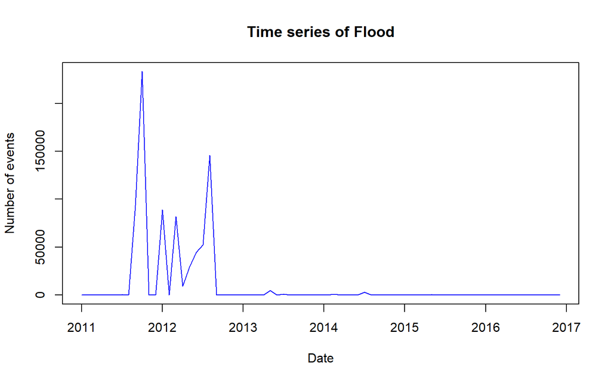

```r
# 2. Flood
dataset_flood <- subset(dataall_na_addcol,EVENT_TYPE=="Flood")
dataset_flood <- dataset_flood[c(9,10)]
dataset_flood$date <- as.Date(dataset_flood$date)
dataset_flood1 <- subset(dataset_flood,subset = DAMAGE_OVERALL>0  , select = c(DAMAGE_OVERALL,date))

ts_flood<- ts(dataset_flood1$DAMAGE_OVERALL,start=c(2011,1),end=c(2016,12),frequency = 12)

plot(ts_flood, type="l",col="blue", xlab = "Date",ylab="Number of events", main = "Time series of Flood")
```

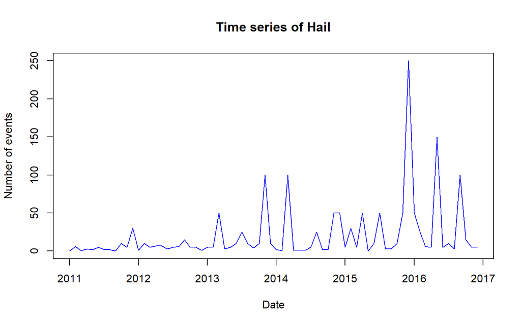

```r
# 3. Hail
dataset_hail <- subset(dataall_na_addcol,EVENT_TYPE=="Hail")
dataset_hail <- dataset_hail[c(9,10)]
dataset_hail$date <- as.Date(dataset_hail$date)
dataset_hail1 <- subset(dataset_hail,subset = DAMAGE_OVERALL>0  , select = c(DAMAGE_OVERALL,date))


ts_hail<- ts(dataset_hail1$DAMAGE_OVERALL,start=c(2011,1),end=c(2016,12),frequency = 12)

plot(ts_hail, type="l",col="blue", xlab = "Date",ylab="Number of events", main = "Time series of Hail")
```

[figure not shown]

```r
# 4. Hurricane

dataset_hurricane <- subset(dataall_na_addcol,EVENT_TYPE=="Hurricane")
dataset_hurricane <- dataset_hurricane[c(9,10)]
dataset_hail$date <- as.Date(dataset_hail$date)
dataset_hurricane1 <- subset(dataset_hurricane,subset = DAMAGE_OVERALL>0  , select = c(DAMAGE_OVERALL,date))



ts_hurricane<- ts(dataset_hurricane1$DAMAGE_OVERALL,start=c(2011,1),end=c(2016,12),frequency = 12)

plot(ts_hurricane, type="l",col="blue", xlab = "Date",ylab="Number of events", main = "Time series of Hurricane")
```

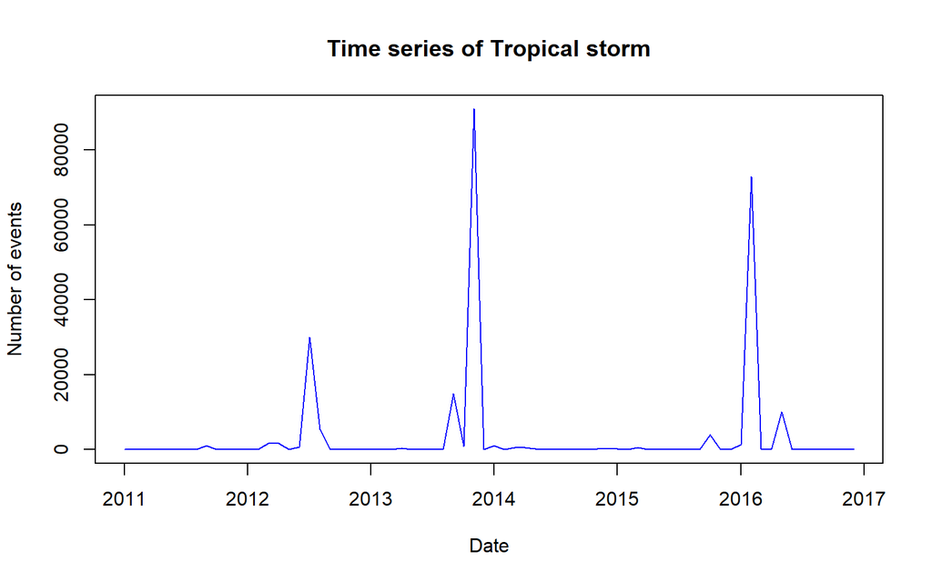

```r
# 5. Tropical Storm

dataset_TropicalStorm <- subset(dataall_na_addcol,EVENT_TYPE=="Tropical Storm")
dataset_TropicalStorm <- dataset_TropicalStorm[c(9,10)]
dataset_TropicalStorm$date <- as.Date(dataset_TropicalStorm$date)
dataset_TropicalStorm1 <- subset(dataset_TropicalStorm,subset = DAMAGE_OVERALL>0  , select = c(DAMAGE_OVERALL,date))



ts_TropicalStorm<- ts(dataset_TropicalStorm1$DAMAGE_OVERALL,start=c(2011,1),end=c(2016,12),frequency = 12)

plot(ts_TropicalStorm, type="l", col="blue", xlab = "Date",ylab="Number of events", main = "Time series of Tropical storm")
```

#### 4.What is the frequency of event occurrence on the monthly basis (month wise occurrence) for year 2016?

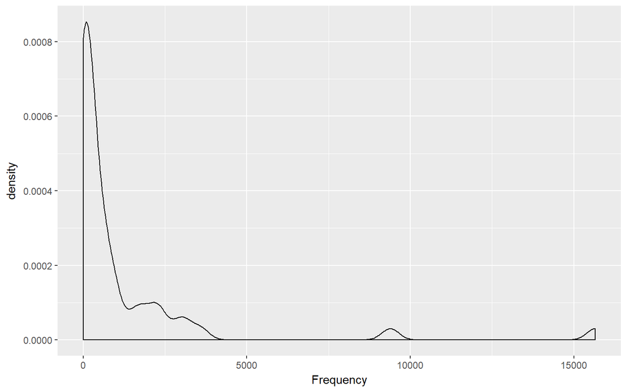

```r
library(knitr)
library(ggplot2)
require(gridExtra)
Dataset=read.csv('StormEvents_details-ftp_v1.0_d2016_c20170918.csv')
Dataset3_month <- Dataset[,c(12,13)]
# Create event table.
event_table=table(Dataset3_month$EVENT_TYPE)
event_table_df<- as.data.frame(event_table)
names(event_table_df)<- c("Event","Frequency")
ggplot(event_table_df, aes(x = Frequency)) + geom_density() +scale_y_continuous(labels = comma) # this plot is to find out which event should be considered for  plotting in clustered graph
```

```r
# So event above 5000 frequency should be considered while plotting
# Making subset of the graphs with frequency above the median of the EVenet Frequency so that we only consider the higher occuring events
event_table_df<- subset(event_table_df,subset=Frequency>median(event_table_df$Frequency), select= c(Event))

#Showing the month with frequency of event occurance-
month_table <- table(Dataset3_month)
table_M<- as.data.frame(month_table)
names(table_M)<- c("Month","Event","Frequency")
mean(table_M$Frequency)
```

```
## [1] 93.265
```

```r
summary(table_M)
```

```
##       Month                       Event       Frequency
##  April   : 50   Astronomical Low Tide: 12   Min.   :   0.00
##  August  : 50   Avalanche            : 12   1st Qu.:   0.00
##  December: 50   Blizzard             : 12   Median :   3.00
##  February: 50   Coastal Flood        : 12   Mean   :  93.27
##  January : 50   Cold/Wind Chill      : 12   3rd Qu.:  48.00
##  July    : 50   Debris Flow          : 12   Max.   :5463.00
##  (Other) :300   (Other)              :528
```

```r
highfreq_event<- subset(table_M,subset=Frequency>350, select= c(Month,Event,Frequency))
highfreq_event1p<- subset(table_M,subset=Frequency>48, select= c(Month,Event,Frequency))

q1<- c("January", "February","March")
q2<- c("April", "May","June")
q3<- c("July", "August","September")
q4<- c("October","November", "December")


highfreq_eventq1<- subset(highfreq_event,subset=Month %in% q1, select= c(Month,Event,Frequency))
highfreq_eventq2<- subset(highfreq_event,subset=Month %in% q2, select= c(Month,Event,Frequency))
highfreq_eventq3<- subset(highfreq_event,subset=Month %in% q3, select= c(Month,Event,Frequency))
highfreq_eventq4<- subset(highfreq_event,subset=Month %in% q4, select= c(Month,Event,Frequency))

#Creating Subset of data for each month-

jan_data <-Dataset3_month[Dataset3_month$MONTH_NAME == 'January',]
feb_data <-Dataset3_month[Dataset3_month$MONTH_NAME == 'February',]
mar_data <-Dataset3_month[Dataset3_month$MONTH_NAME == 'March',]
apr_data <-Dataset3_month[Dataset3_month$MONTH_NAME == 'April',]
may_data <-Dataset3_month[Dataset3_month$MONTH_NAME == 'May',]
jun_data <-Dataset3_month[Dataset3_month$MONTH_NAME == 'June',]
jul_data <-Dataset3_month[Dataset3_month$MONTH_NAME == 'July',]
aug_data <-Dataset3_month[Dataset3_month$MONTH_NAME == 'August',]
sep_data <-Dataset3_month[Dataset3_month$MONTH_NAME == 'September',]
oct_data <-Dataset3_month[Dataset3_month$MONTH_NAME == 'October',]
nov_data <-Dataset3_month[Dataset3_month$MONTH_NAME == 'November',]
dec_data <-Dataset3_month[Dataset3_month$MONTH_NAME == 'December',]

# Creating Plot For each month-

table_16 <- table(jan_data$EVENT_TYPE)
df16<- as.data.frame(table_16)
names(df16)<- c("EventType","Frequency")
summary(df16)# Check for Q3 So as to select the event greater than third Quartile
```

```
##                  EventType    Frequency
##  Astronomical Low Tide: 1   Min.   :  0.00
##  Avalanche            : 1   1st Qu.:  0.00
##  Blizzard             : 1   Median :  7.50
##  Coastal Flood        : 1   Mean   : 61.52
##  Cold/Wind Chill      : 1   3rd Qu.: 51.25
##  Debris Flow          : 1   Max.   :754.00
##  (Other)              :44
```

```r
df16.1<- subset(df16,subset=Frequency>50, select= c(EventType,Frequency))
pjan <-  ggplot(df16.1, aes(x=EventType, y = Frequency))+geom_col()+ theme(axis.text.x = element_text(angle = 45, hjust =1))+labs(title = "January Events",x="Event", y="Frequency")

table_feb <- table(feb_data$EVENT_TYPE)
data_feb<- as.data.frame(table_feb)
names(data_feb)<- c("EventType","Frequency")
summary(data_feb)# Check for Q3 So as to select the event greater than third Quartile
```

```
##                  EventType    Frequency
##  Astronomical Low Tide: 1   Min.   :  0.00
##  Avalanche            : 1   1st Qu.:  0.00
##  Blizzard             : 1   Median :  8.50
##  Coastal Flood        : 1   Mean   : 97.48
##  Cold/Wind Chill      : 1   3rd Qu.: 84.50
##  Debris Flow          : 1   Max.   :814.00
##  (Other)              :44
```

```r
data_feb<- subset(data_feb,subset=Frequency>51, select= c(EventType,Frequency))
pfeb <-  ggplot(data_feb, aes(x=EventType, y = Frequency))+geom_col()+ theme(axis.text.x = element_text(angle = 45, hjust =1))+labs(title = "February Events",x="Event", y="Frequency")

table_mar <- table(mar_data$EVENT_TYPE)
data_mar<- as.data.frame(table_mar)
names(data_mar)<- c("EventType","Frequency")
summary(data_mar)# Check for Q3 So as to select the event greater than third Quartile
```

```
##                  EventType    Frequency
##  Astronomical Low Tide: 1   Min.   :  0.00
##  Avalanche            : 1   1st Qu.:  0.00
##  Blizzard             : 1   Median :  3.00
##  Coastal Flood        : 1   Mean   : 78.22
##  Cold/Wind Chill      : 1   3rd Qu.: 37.75
##  Debris Flow          : 1   Max.   :918.00
##  (Other)              :44
```

```r
data_mar<- subset(data_mar,subset=Frequency>38, select= c(EventType,Frequency))
pmar <-  ggplot(data_mar, aes(x=EventType, y = Frequency))+geom_col()+ theme(axis.text.x = element_text(angle = 45, hjust =1))+labs(title = "March Events",x="Event", y="Frequency")

table_apr <- table(apr_data$EVENT_TYPE)
data_apr<- as.data.frame(table_apr)
names(data_apr)<- c("EventType","Frequency")
summary(data_apr)# Check for Q3 So as to select the event greater than third Quartile
```

```
##                  EventType    Frequency
##  Astronomical Low Tide: 1   Min.   :   0.00
##  Avalanche            : 1   1st Qu.:   0.00
##  Blizzard             : 1   Median :   3.00
##  Coastal Flood        : 1   Mean   :  98.92
##  Cold/Wind Chill      : 1   3rd Qu.:  54.75
##  Debris Flow          : 1   Max.   :1386.00
##  (Other)              :44
```

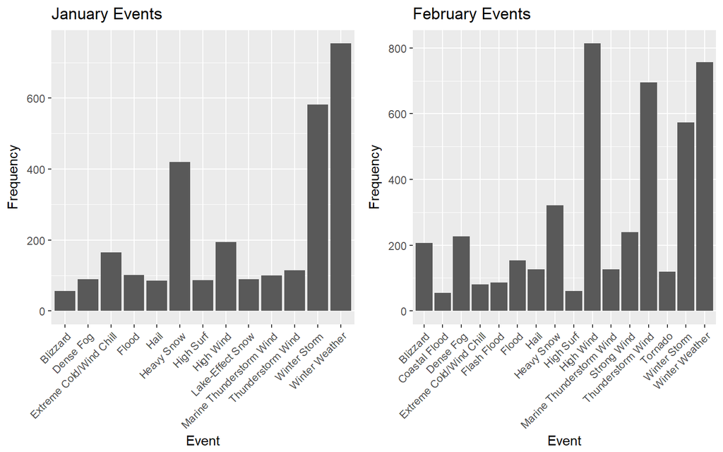

```r
data_apr<- subset(data_apr,subset=Frequency>54, select= c(EventType,Frequency))
papr <-  ggplot(data_apr, aes(x=EventType, y = Frequency))+geom_col()+ theme(axis.text.x = element_text(angle = 45, hjust =1))+labs(title = "April Events",x="Event", y="Frequency")

grid.arrange(pjan, pfeb, ncol = 2)
```

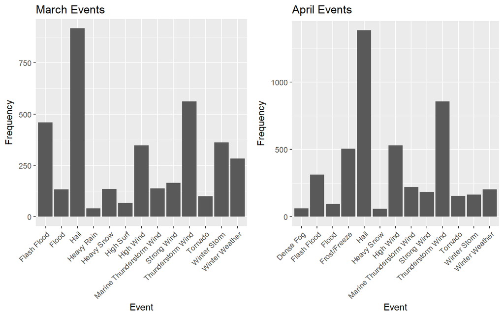

```r
grid.arrange(pmar, papr, ncol = 2)
```

In above graph we can see the frequency of events and which event is occurring most in the particular months. Plots are created for other months till december.

```r
table_may <- table(may_data$EVENT_TYPE)
data_may<- as.data.frame(table_may)
names(data_may)<- c("EventType","Frequency")
summary(data_may)# Check for Q3 So as to select the event greater than third Quartile
```

```
##                  EventType    Frequency
##  Astronomical Low Tide: 1   Min.   :   0.00
##  Avalanche            : 1   1st Qu.:   0.00
##  Blizzard             : 1   Median :   3.00
##  Coastal Flood        : 1   Mean   : 112.10
##  Cold/Wind Chill      : 1   3rd Qu.:  18.25
##  Debris Flow          : 1   Max.   :2576.00
##  (Other)              :44
```

```r
data_may<- subset(data_may,subset=Frequency>18, select= c(EventType,Frequency))
pmay <-  ggplot(data_may, aes(x=EventType, y = Frequency))+geom_col()+ theme(axis.text.x = element_text(angle = 45, hjust =1))+labs(title = "May Events",x="Event", y="Frequency")


table_jun<- table(jun_data$EVENT_TYPE)
data_jun<- as.data.frame(table_jun)
names(data_jun)<- c("EventType","Frequency")
summary(data_jun)# Check for Q3 So as to select the event greater than third Quartile
```

```
##                  EventType    Frequency
##  Astronomical Low Tide: 1   Min.   :   0.00
##  Avalanche            : 1   1st Qu.:   0.00
##  Blizzard             : 1   Median :   3.00
##  Coastal Flood        : 1   Mean   : 132.24
##  Cold/Wind Chill      : 1   3rd Qu.:  31.75
##  Debris Flow          : 1   Max.   :3461.00
##  (Other)              :44
```

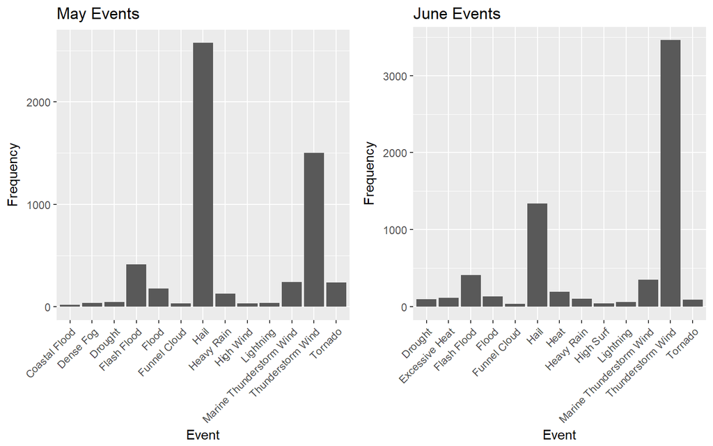

```r
data_jun<- subset(data_jun,subset=Frequency>32, select= c(EventType,Frequency))
pjun <-  ggplot(data_jun, aes(x=EventType, y = Frequency))+geom_col()+ theme(axis.text.x = element_text(angle = 45, hjust =1))+labs(title = "June Events",x="Event", y="Frequency")

grid.arrange(pmay, pjun, ncol = 2)
```

```r
table_jul<- table(jul_data$EVENT_TYPE)
data_jul<- as.data.frame(table_jul)
names(data_jul)<- c("EventType","Frequency")
summary(data_jul)# Check for Q3 So as to select the event greater than third Quartile
```

```
##                  EventType    Frequency
##  Astronomical Low Tide: 1   Min.   :   0.0
##  Avalanche            : 1   1st Qu.:   0.0
##  Blizzard             : 1   Median :   0.0
##  Coastal Flood        : 1   Mean   : 197.9
##  Cold/Wind Chill      : 1   3rd Qu.:  53.5
##  Debris Flow          : 1   Max.   :5463.0
##  (Other)              :44
```

```r
data_jul<- subset(data_jul,subset=Frequency>53, select= c(EventType,Frequency))
pjul <-  ggplot(data_jul, aes(x=EventType, y = Frequency))+geom_col()+ theme(axis.text.x = element_text(angle = 45, hjust =1))+labs(title = "July Events",x="Event", y="Frequency")



table_aug<- table(aug_data$EVENT_TYPE)
data_aug<- as.data.frame(table_aug)
names(data_aug)<- c("EventType","Frequency")
summary(data_aug)# Check for Q3 So as to select the event greater than third Quartile
```

```
##                  EventType    Frequency
##  Astronomical Low Tide: 1   Min.   :   0.00
##  Avalanche            : 1   1st Qu.:   0.00
##  Blizzard             : 1   Median :   0.50
##  Coastal Flood        : 1   Mean   :  96.64
##  Cold/Wind Chill      : 1   3rd Qu.:  39.00
##  Debris Flow          : 1   Max.   :1710.00
##  (Other)              :44
```

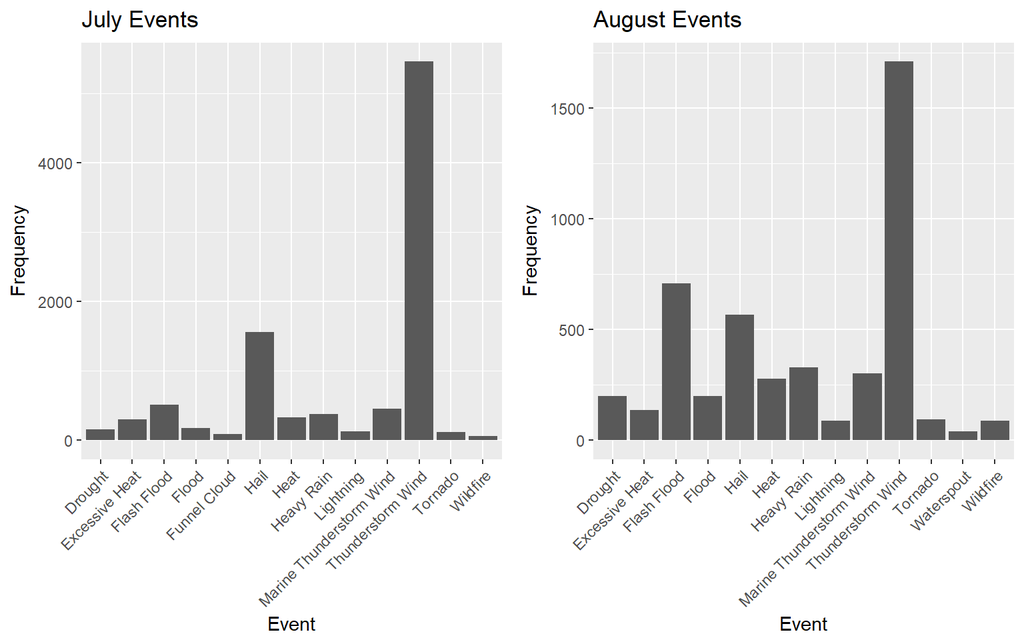

```r
data_aug<- subset(data_aug,subset=Frequency>39, select= c(EventType,Frequency))
paug <-  ggplot(data_aug, aes(x=EventType, y = Frequency))+geom_col()+ theme(axis.text.x = element_text(angle = 45, hjust =1))+labs(title = "August Events",x="Event", y="Frequency")

grid.arrange(pjul, paug, ncol = 2)
```

```r
table_sep<- table(sep_data$EVENT_TYPE)
data_sep<- as.data.frame(table_sep)
names(data_sep)<- c("EventType","Frequency")
summary(data_sep)# Check for Q3 So as to select the event greater than third Quartile
```

```
##                  EventType    Frequency
##  Astronomical Low Tide: 1   Min.   :  0.00
##  Avalanche            : 1   1st Qu.:  0.00
##  Blizzard             : 1   Median :  5.00
##  Coastal Flood        : 1   Mean   : 65.66
##  Cold/Wind Chill      : 1   3rd Qu.: 26.25
##  Debris Flow          : 1   Max.   :747.00
##  (Other)              :44
```

```r
data_sep<- subset(data_sep,subset=Frequency>27, select= c(EventType,Frequency))
psep <-  ggplot(data_sep, aes(x=EventType, y = Frequency))+geom_col()+ theme(axis.text.x = element_text(angle = 45, hjust =1))+labs(title = "September Events",x="Event", y="Frequency")


table_oct<- table(oct_data$EVENT_TYPE)
data_oct<- as.data.frame(table_oct)
names(data_oct)<- c("EventType","Frequency")
summary(data_oct)# Check for Q3 So as to select the event greater than third Quartile
```

```
##                  EventType    Frequency
##  Astronomical Low Tide: 1   Min.   :  0.00
##  Avalanche            : 1   1st Qu.:  0.00
##  Blizzard             : 1   Median :  7.50
##  Coastal Flood        : 1   Mean   : 46.88
##  Cold/Wind Chill      : 1   3rd Qu.: 49.00
##  Debris Flow          : 1   Max.   :331.00
##  (Other)              :44
```

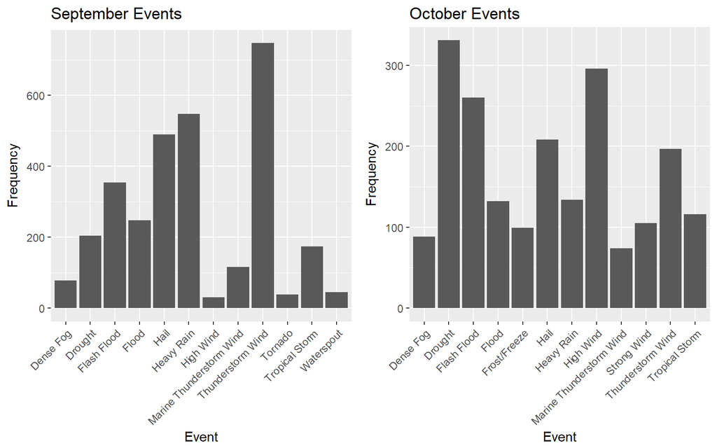

```r
data_oct<- subset(data_oct,subset=Frequency>49, select= c(EventType,Frequency))
poct <-  ggplot(data_oct, aes(x=EventType, y = Frequency))+geom_col()+ theme(axis.text.x = element_text(angle = 45, hjust =1))+labs(title = "October Events",x="Event", y="Frequency")

grid.arrange(psep, poct, ncol = 2)
```

```r
table_nov<- table(nov_data$EVENT_TYPE)
data_nov<- as.data.frame(table_nov)
names(data_nov)<- c("EventType","Frequency")
summary(data_nov)# Check for Q3 So as to select the event greater than third Quartile
```

```
##                  EventType    Frequency
##  Astronomical Low Tide: 1   Min.   :  0.00
##  Avalanche            : 1   1st Qu.:  0.00
##  Blizzard             : 1   Median :  1.00
##  Coastal Flood        : 1   Mean   : 41.32
##  Cold/Wind Chill      : 1   3rd Qu.: 39.25
##  Debris Flow          : 1   Max.   :610.00
##  (Other)              :44
```

```r
data_nov<- subset(data_nov,subset=Frequency>39, select= c(EventType,Frequency))
pnov <-  ggplot(data_nov, aes(x=EventType, y = Frequency))+geom_col()+ theme(axis.text.x = element_text(angle = 45, hjust =1))+labs(title = "November Events",x="Event", y="Frequency")


table_dec<- table(dec_data$EVENT_TYPE)
data_dec<- as.data.frame(table_dec)
names(data_dec)<- c("EventType","Frequency")
summary(data_dec)# Check for Q3 So as to select the event greater than third Quartile
```

```
##                  EventType    Frequency
##  Astronomical Low Tide: 1   Min.   :  0.00
##  Avalanche            : 1   1st Qu.:  0.00
##  Blizzard             : 1   Median :  6.00
##  Coastal Flood        : 1   Mean   : 90.28
##  Cold/Wind Chill      : 1   3rd Qu.: 71.50
##  Debris Flow          : 1   Max.   :738.00
##  (Other)              :44
```

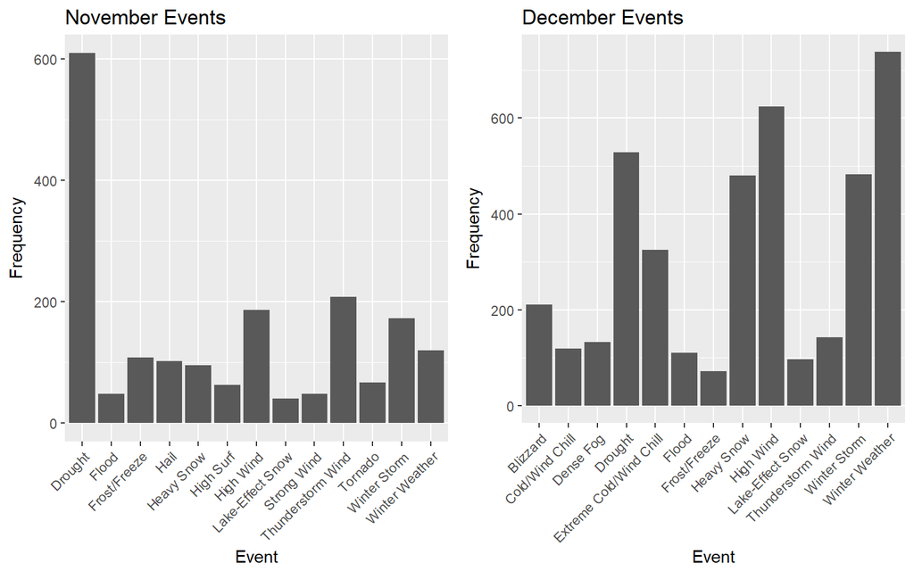

```r
data_dec<- subset(data_dec,subset=Frequency>71, select= c(EventType,Frequency))
pdec <-  ggplot(data_dec, aes(x=EventType, y = Frequency))+geom_col()+ theme(axis.text.x = element_text(angle = 45, hjust =1))+labs(title = "December Events",x="Event", y="Frequency")

grid.arrange(pnov, pdec, ncol = 2)
```

Following graph shows the occurrence of total events in each month. We can see that July has the highest number of events occurring followed by June and May. This graph helps in understanding of event counts against month of 2016.

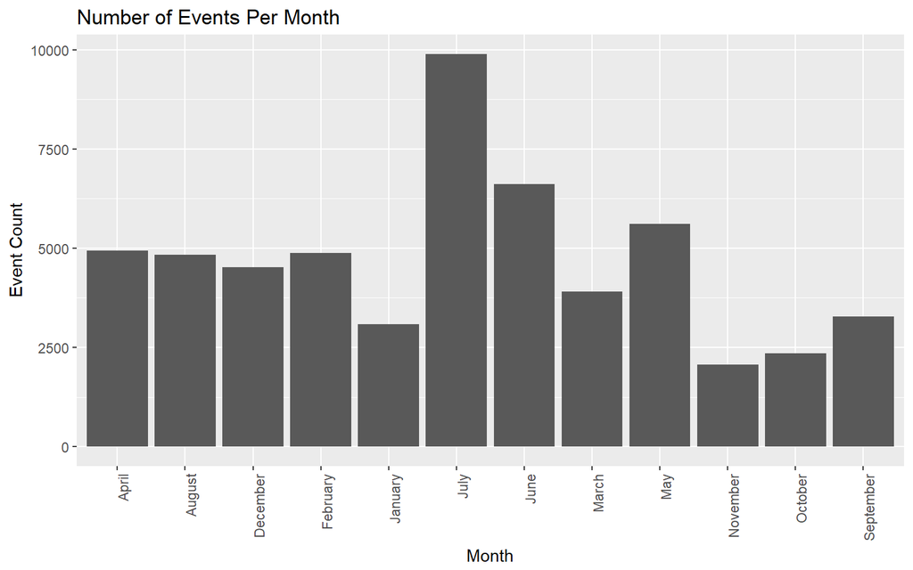

```r
ggplot(Dataset3_month, aes(x = MONTH_NAME)) + geom_bar()+theme(axis.text.x = element_text(angle = 90, hjust =1))+labs(title = "Number of Events Per Month",x="Month", y="Event Count")
```

Following graph shows the nnumber of events in each month with the distribution/frequency of all events. Here, in July (month having the most events) has thunderstorm and hail as predominant events. Throughout the months, these two events are mostly occurring.

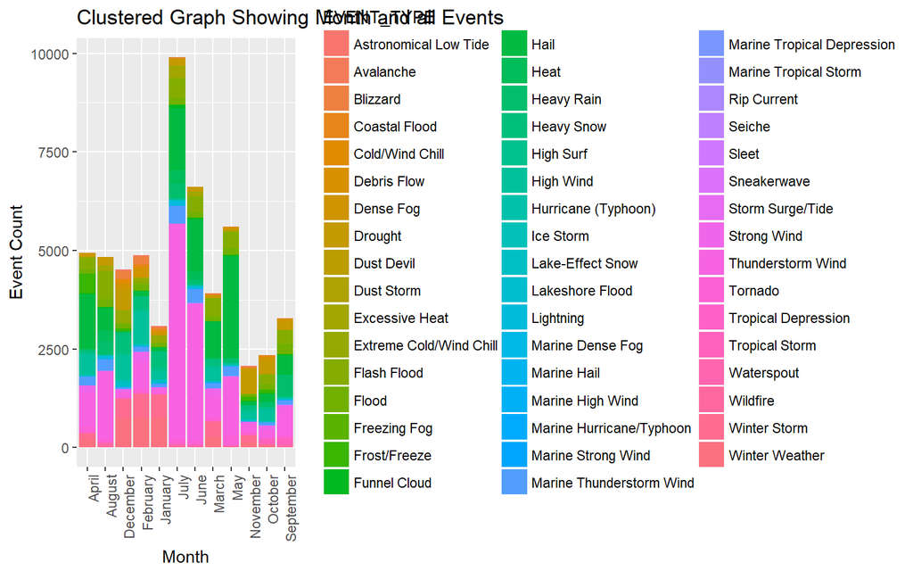

```r
# THIS SHOWS WHICH MONTH HAS HOW MANY EVENTS OCCURING

ggplot(Dataset3_month, aes(x = MONTH_NAME, fill = EVENT_TYPE)) + geom_bar()+
   theme(axis.text.x = element_text(angle = 90, hjust =1))+
  labs(title = "Clustered Graph Showing Month and all Events",x="Month", y="Event Count")
```

Following graph is same as the above one, only difference is only the high occurring event types are taken on the basis of the analysis above. Here higher frequency greater than 350 is taken. Thus in october, not any event has occured more than 350 times. Thus its not seen in graph.

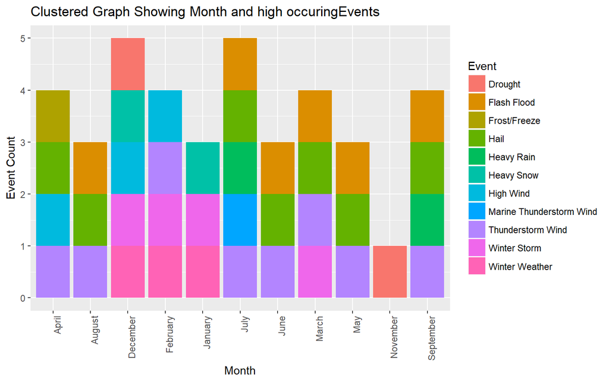

```r
ggplot(highfreq_event, aes(x = Month, fill = Event)) + geom_bar()+
   theme(axis.text.x = element_text(angle = 90, hjust =1))+labs(title = "Clustered Graph Showing Month and high occuringEvents",x="Month", y="Event Count")
```

[figure not shown]

```r
ggplot(highfreq_event, aes(x = Month, fill = Event)) + geom_bar()+
   theme(axis.text.x = element_text(angle = 90, hjust =1))+labs(title = "Clustered Graph Showing Month and high occuringEvents",x="Month", y="Event Count")
```

Following graphs are refined version of graphs made earlier. Events with higher frequency of occurrence are only shown, thus less number of events can be seen thatn in previous graphs, and will be easy to analyze.

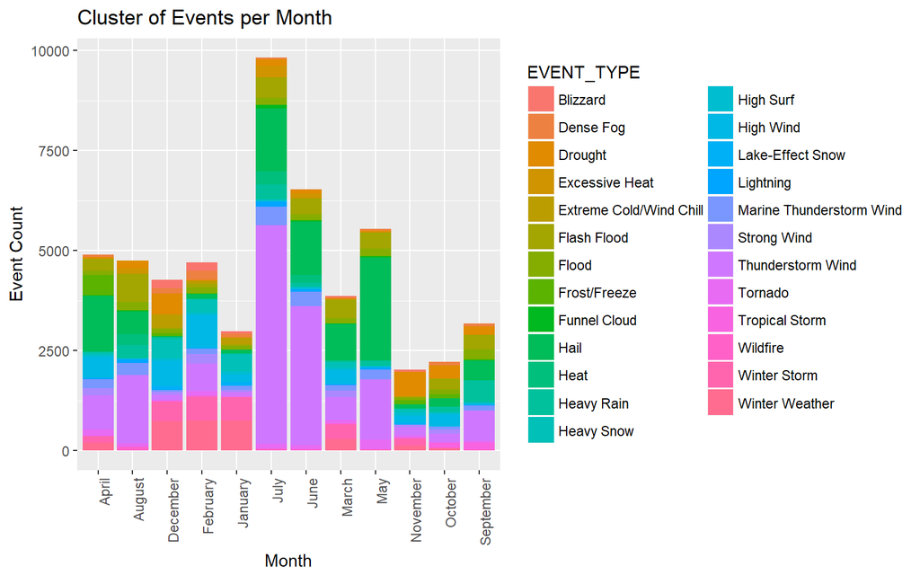

```r
## Graphing for higher occuring events-
sub_event<- event_table_df[["Event"]]

#making subset using event_table_df
highevents<- subset(Dataset3_month, EVENT_TYPE %in% sub_event )
# Clustered Graphs
ggplot(highevents, aes(x = MONTH_NAME, fill = EVENT_TYPE)) + geom_bar()+theme(axis.text.x = element_text(angle = 90, hjust =1))+labs(title = "Cluster of Events per Month",x="Month", y="Event Count")
```

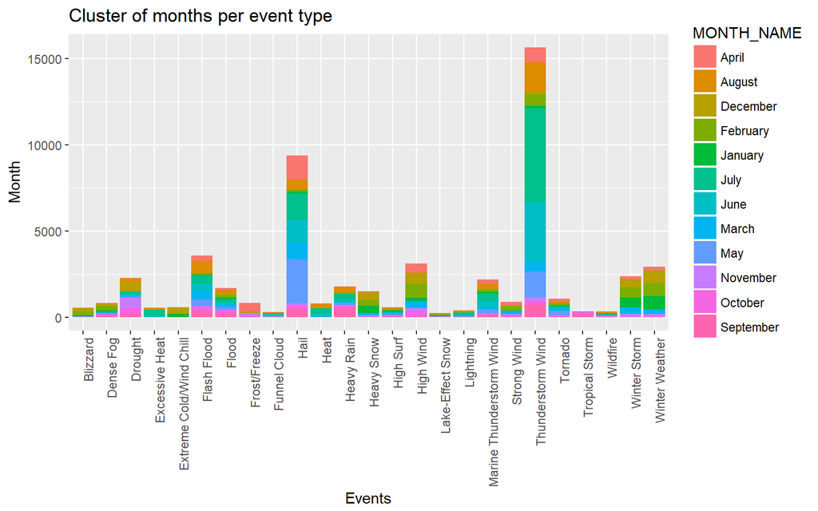

```r
ggplot(highevents, aes(x = EVENT_TYPE, fill = MONTH_NAME)) + geom_bar()+ theme(axis.text.x = element_text(angle = 90, hjust =1))+labs(title = "Cluster of months per event type",x="Events", y="Month")
```

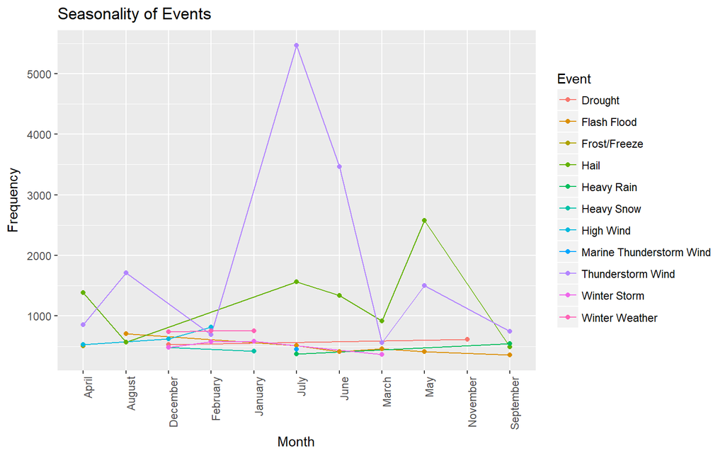

```r
# Line Graph Showing the frequency of Events by month (Showing Seasonality of Event Types)
ggplot(data=highfreq_event, aes(x=Month, y=Frequency, group=Event)) +
  geom_line(aes(color=Event))+
  geom_point(aes(color=Event))+theme(axis.text.x = element_text(angle = 90, hjust =1))+labs(title = "Seasonality of Events",x="Month", y="Frequency")
```

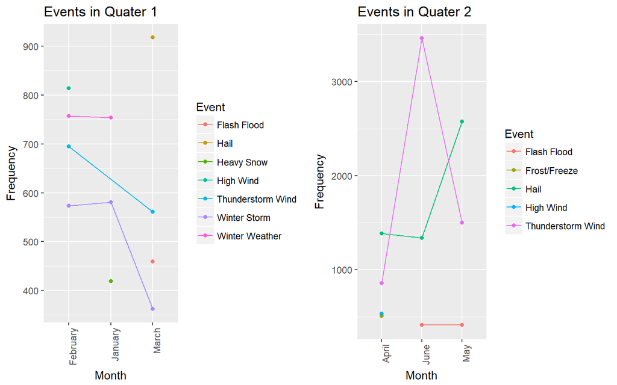

```r
# for quater 1-
ggplotq1<-ggplot(data=highfreq_eventq1, aes(x=Month, y=Frequency, group=Event)) +
  geom_line(aes(color=Event))+
  geom_point(aes(color=Event))+theme(axis.text.x = element_text(angle = 90, hjust =1))+labs(title = "Events in Quater 1",x="Month", y="Frequency")

# Plot for  quater 2-
ggplotq2 <- ggplot(data=highfreq_eventq2, aes(x=Month, y=Frequency, group=Event)) +
  geom_line(aes(color=Event))+
  geom_point(aes(color=Event))+theme(axis.text.x = element_text(angle = 90, hjust =1))+labs(title = "Events in Quater 2",x="Month", y="Frequency")


grid.arrange(ggplotq1, ggplotq2, ncol = 2)
```

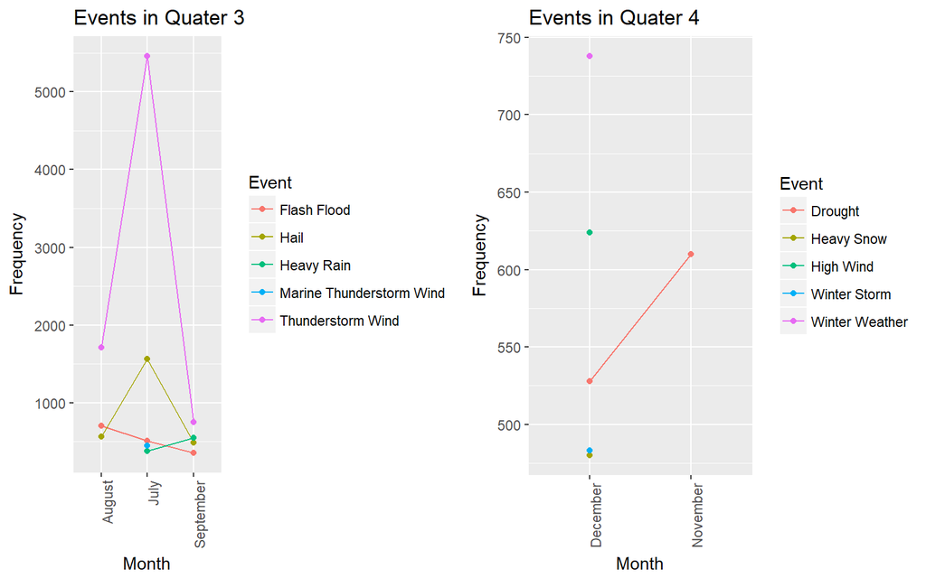

```r
# Plot for Quater 3-
ggplotq3 <- ggplot(data=highfreq_eventq3, aes(x=Month, y=Frequency, group=Event)) +
  geom_line(aes(color=Event))+
  geom_point(aes(color=Event))+theme(axis.text.x = element_text(angle = 90, hjust =1))+labs(title = "Events in Quater 3",x="Month", y="Frequency")

# Plot for Quater 4-
ggplotq4 <- ggplot(data=highfreq_eventq4, aes(x=Month, y=Frequency, group=Event)) +
  geom_line(aes(color=Event))+
  geom_point(aes(color=Event))+theme(axis.text.x = element_text(angle = 90, hjust =1))+labs(title = "Events in Quater 4",x="Month", y="Frequency")

grid.arrange(ggplotq3, ggplotq4, ncol = 2)
```